# NETN water summary

##### Northeast Temperate Network

##### Inventory & Monitoring Program

##### Water Quality Summaries

[figure not shown]

##### National Park Service

##### U.S. Department of the Interior

# NETN water summary

# Marsh-Billings-Rockefeller National Historical Park

## Water Quality

### Status

#### Pogue Brook

##### Physical

## Historic (2006 to 2022) vs. Current (2023)

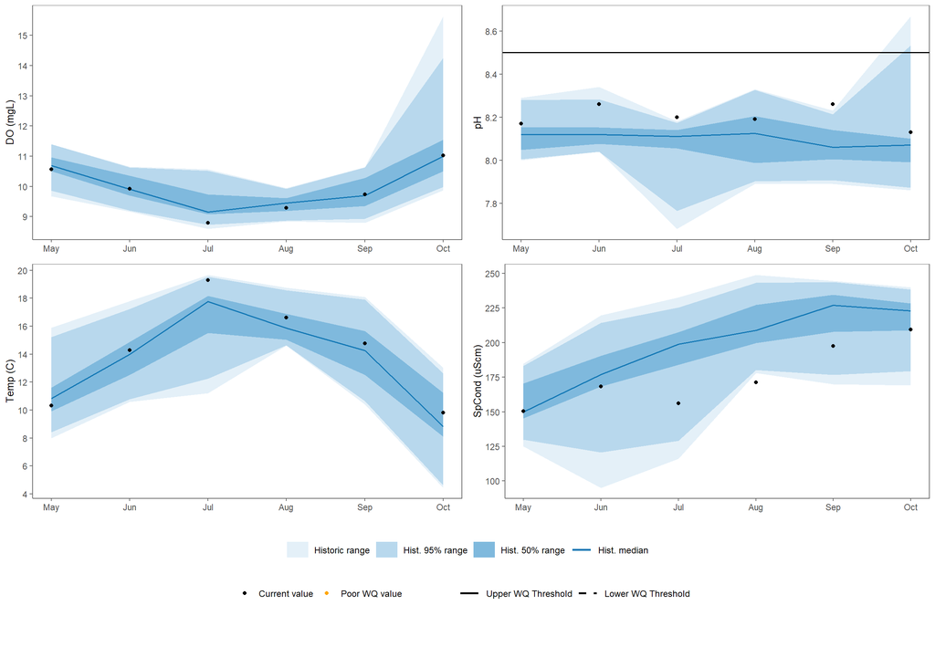

The plots above show historic ranges for Pogue Brook based on the range of measurements collected from 2006 to 2022 for each month. The outermost band represents the historic maximum and minimum value collected for each month. The second inner band represents the 95% range of historic values by month. The innermost band represents the 50% range of historic values by month. The points represent the most recent measurements collected in 2023 by month. Water quality thresholds are derived from state surface water quality standards. Parameter abbreviations and additional information are defined in “About the Data”.

##### Nutrient

## Historic (2006 to 2022) vs. Current (2023)

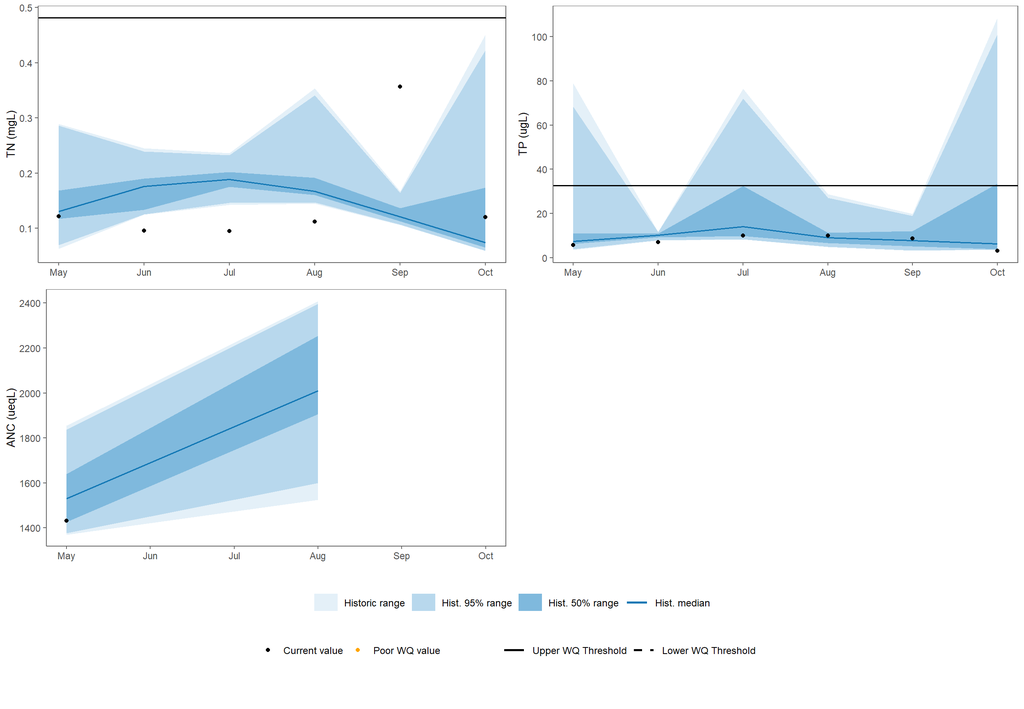

The plots above show historic ranges for Pogue Brook based on the range of measurements collected from 2006 to 2022 for each month. The outermost band represents the historic maximum and minimum value collected for each month. The second inner band represents the 95% range of historic values by month. The innermost band represents the 50% range of historic values by month. The points represent the most recent measurements collected in 2023 by month. Water quality thresholds are derived from state surface water quality standards. Parameter abbreviations and additional information are defined in “About the Data”.

#### The Pogue

##### Physical

## Historic (2006 to 2022) vs. Current (2023)

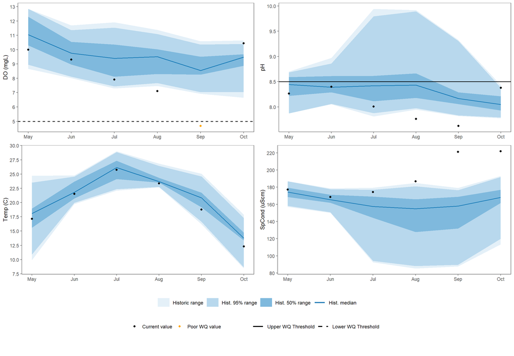

The plots above show historic ranges for The Pogue based on the range of measurements collected from 2006 to 2022 for each month. The outermost band represents the historic maximum and minimum value collected for each month. The second inner band represents the 95% range of historic values by month. The innermost band represents the 50% range of historic values by month. The points represent the most recent measurements collected in 2023 by month. Water quality thresholds are derived from state surface water quality standards. Parameter abbreviations and additional information are defined in “About the Data”.

##### Nutrient

## Historic (2006 to 2022) vs. Current (2023)

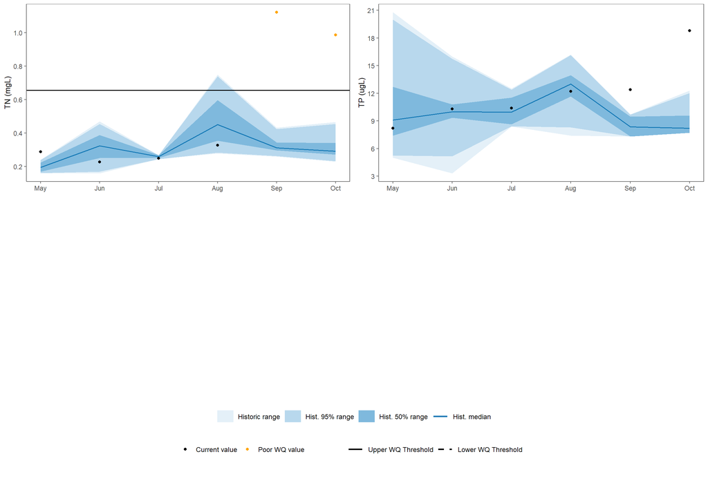

The plots above show historic ranges for The Pogue based on the range of measurements collected from 2006 to 2022 for each month. The outermost band represents the historic maximum and minimum value collected for each month. The second inner band represents the 95% range of historic values by month. The innermost band represents the 50% range of historic values by month. The points represent the most recent measurements collected in 2023 by month. Water quality thresholds are derived from state surface water quality standards. Parameter abbreviations and additional information are defined in “About the Data”.

### Trends

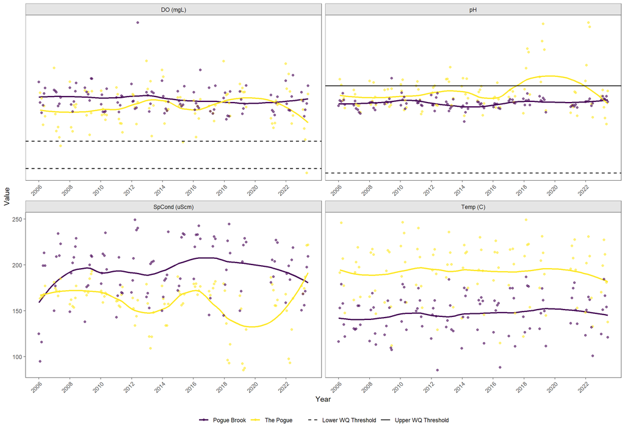

## Climate

### Current Year

# Current vs. 20th Century Baseline

**Temperature**

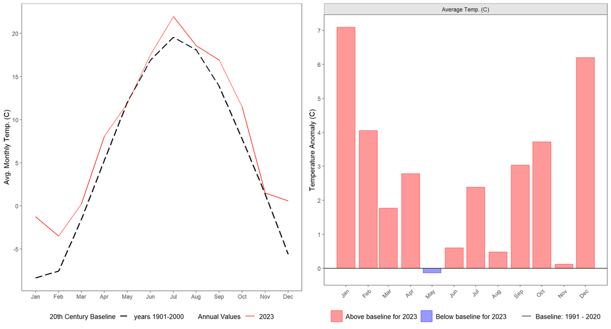

Figure on the left compares current monthly climate data (solid) with historic baselines (dashed). Figure on the right represents monthly deviations from historic baselines, with positive (red) bars indicating above average deviations, and negative (blue) bars indicating below average deviations. Historic baselines are based on [NOAA 20th century normals](https://www.ncei.noaa.gov/products/land-based-station/us-climate-normals) for a given park’s geographic centroid. Current monthly data are derived from [NOAA NClimGrid](https://www.ncei.noaa.gov/access/metadata/landing-page/bin/iso?id=gov.noaa.ncdc:C00332) gridded climate dataset extracted for a given park’s geographic centroid.

**Precipitation**

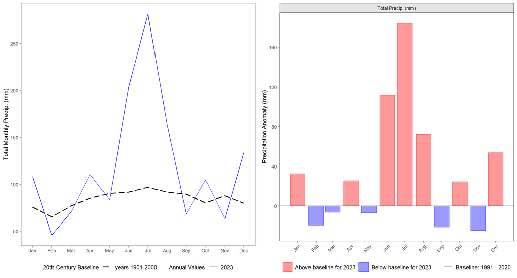

Figure on the left compares current monthly climate data (solid) with historic baselines (dashed). Figure on the right represents monthly deviations from historic baselines, with positive (red) bars indicating above average deviations, and negative (blue) bars indicating below average deviations. Historic baselines are based on [NOAA 20th century normals](https://www.ncei.noaa.gov/products/land-based-station/us-climate-normals) for a given park’s geographic centroid. Current monthly data are derived from [NOAA NClimGrid](https://www.ncei.noaa.gov/access/metadata/landing-page/bin/iso?id=gov.noaa.ncdc:C00332) gridded climate dataset extracted for a given park’s geographic centroid.

**Drought Condition**

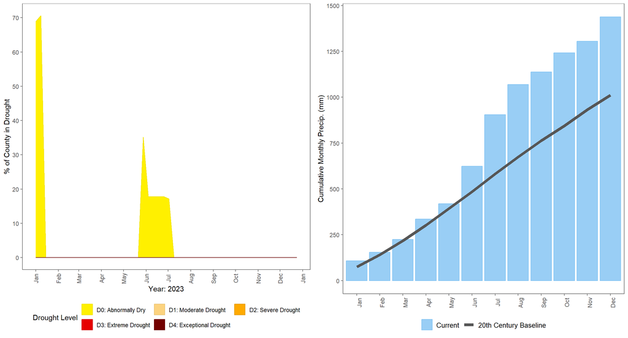

### 5-year Trends

# 5-year vs. 20th Century Baseline

**Temperature**

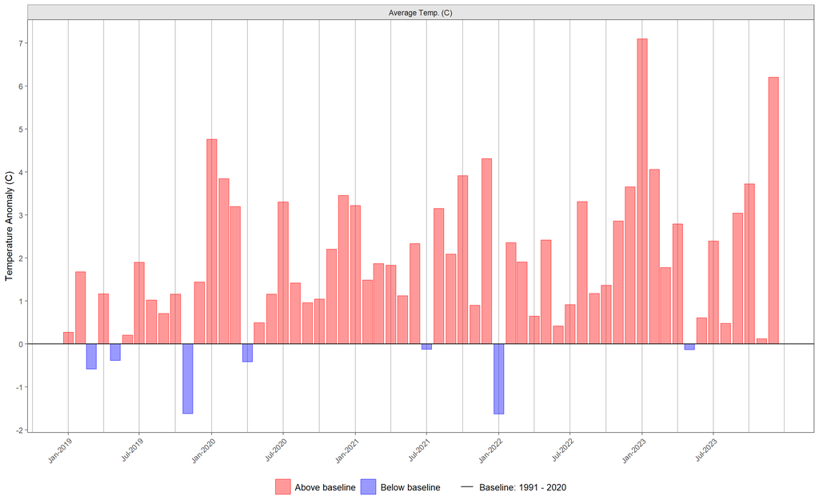

Figure represents monthly deviations from historic baselines, with positive (red) bars, indicated above average deviations, and negative (blue) bars indicating below average deviations. Historic baselines are based on [NOAA 20th century normals](https://www.ncei.noaa.gov/products/land-based-station/us-climate-normals) for a given park’s geographic centroid. 5-year monthly data are derived from [NOAA NClimGrid](https://www.ncei.noaa.gov/access/metadata/landing-page/bin/iso?id=gov.noaa.ncdc:C00332) gridded climate dataset extracted for a given park’s geographic centroid.

**Total Precipitation**

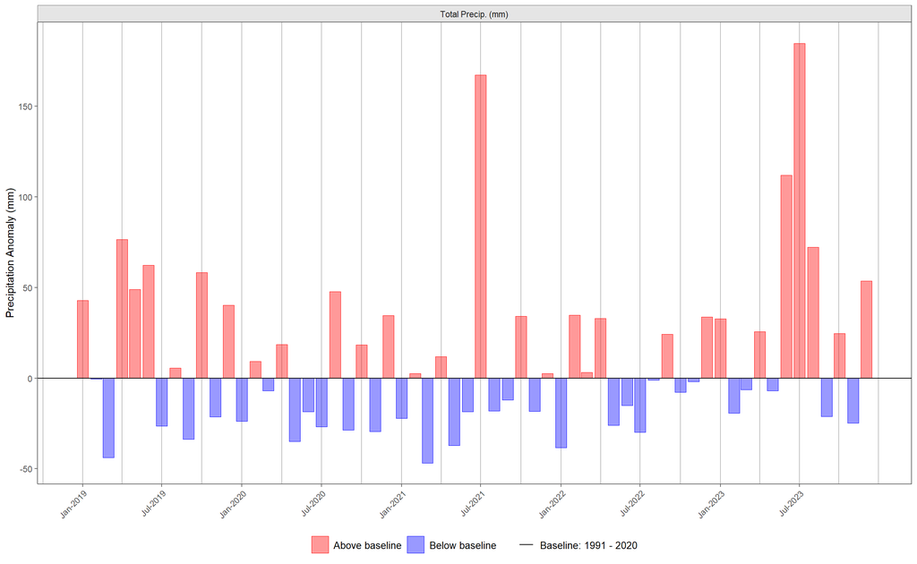

Figure represents monthly deviations from historic baselines, with positive (red) bars, indicated above average deviations, and negative (blue) bars indicating below average deviations. Historic baselines are based on [NOAA 20th century normals](https://www.ncei.noaa.gov/products/land-based-station/us-climate-normals) for a given park’s geographic centroid. 5-year monthly data are derived from [NOAA NClimGrid](https://www.ncei.noaa.gov/access/metadata/landing-page/bin/iso?id=gov.noaa.ncdc:C00332) gridded climate dataset extracted for a given park’s geographic centroid.

**Cumulative Precipitation**

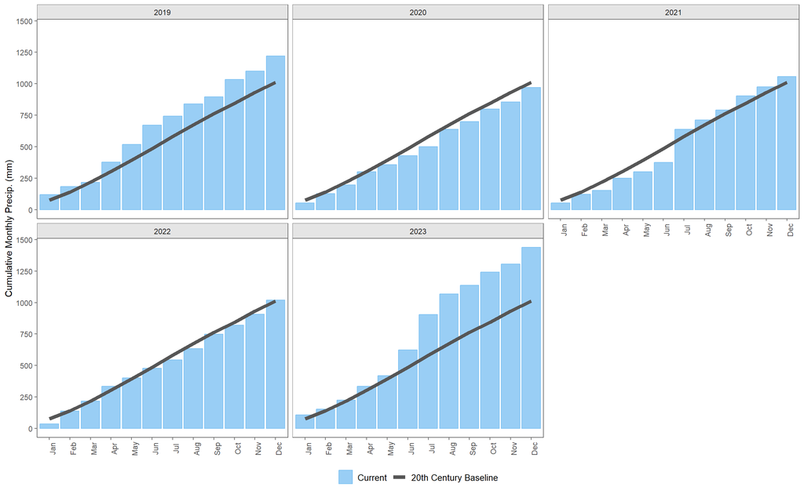

Figure shows cumulative annual precipitation by month for past 5 years compared to the 20th century baseline. Total monthly precipitation data are derived from [NOAA monthly NClimGrid gridded climate data](https://www.ncei.noaa.gov/access/metadata/landing-page/bin/iso?id=gov.noaa.ncdc:C00332) extracted for a given park’s geographic centroid.

**Drought Condition**

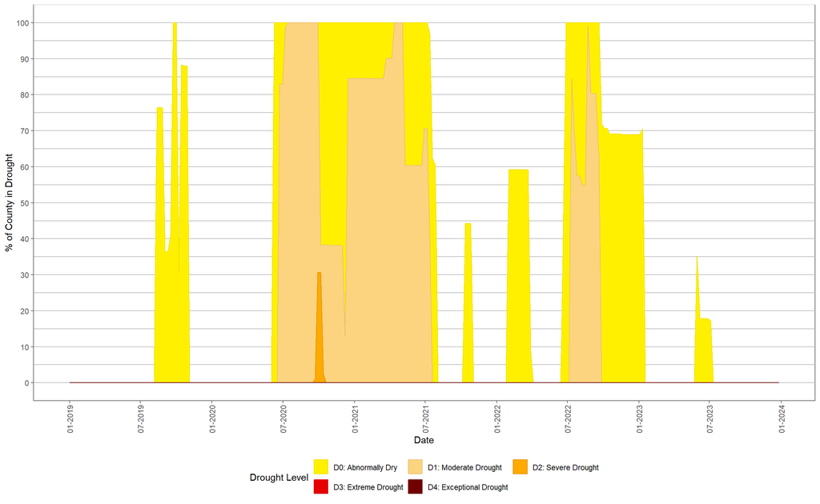

[output not shown]

### Long-term Trends

# Historic Trends 1900:2023

**Temperature Trends**

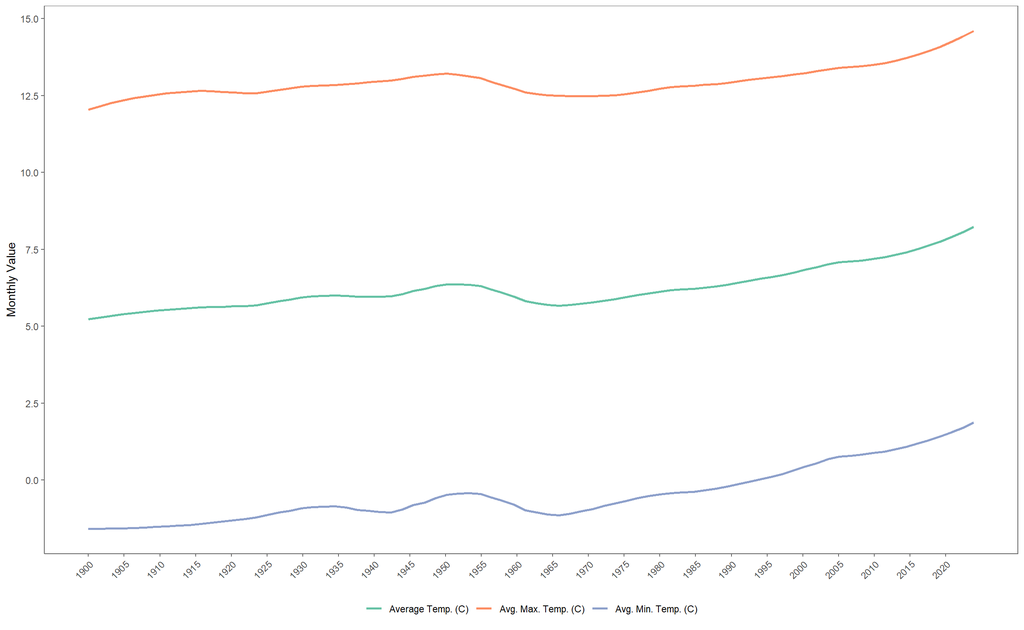

Figure shows loess smoothed (span 0.3) minimum, maximum, and average temperature trends by month derived from [NOAA NClimGrid](https://www.ncei.noaa.gov/access/metadata/landing-page/bin/iso?id=gov.noaa.ncdc:C00332) gridded climate dataset extracted for a given park’s geographic centroid.

**Temperature Anomalies**

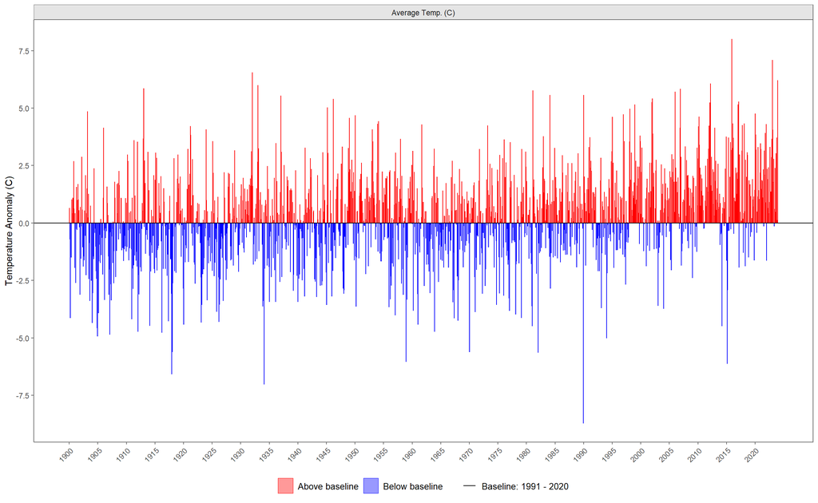

Figure represents monthly deviations from historic baselines, with positive (red) bars, indicated above average deviations, and negative (blue) bars indicating below average deviations. Historic baselines are based on [NOAA 20th century normals](https://www.ncei.noaa.gov/products/land-based-station/us-climate-normals) for a given park’s geographic centroid. Monthly data are derived from [NOAA NClimGrid](https://www.ncei.noaa.gov/access/metadata/landing-page/bin/iso?id=gov.noaa.ncdc:C00332) gridded climate dataset extracted for a given park’s geographic centroid.

**Precipitation Trends**

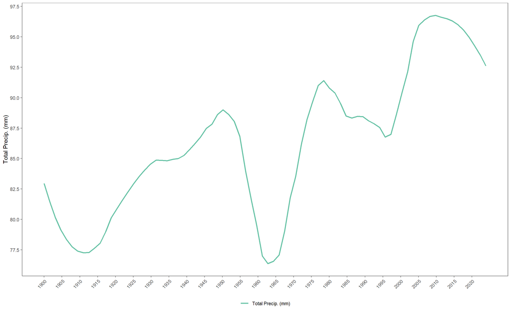

Figure shows loess smoothed (span 0.3) total precipitation trends by month derived from [NOAA NClimGrid](https://www.ncei.noaa.gov/access/metadata/landing-page/bin/iso?id=gov.noaa.ncdc:C00332) gridded climate dataset extracted for a given park’s geographic centroid.

**Precipitation Anomalies**

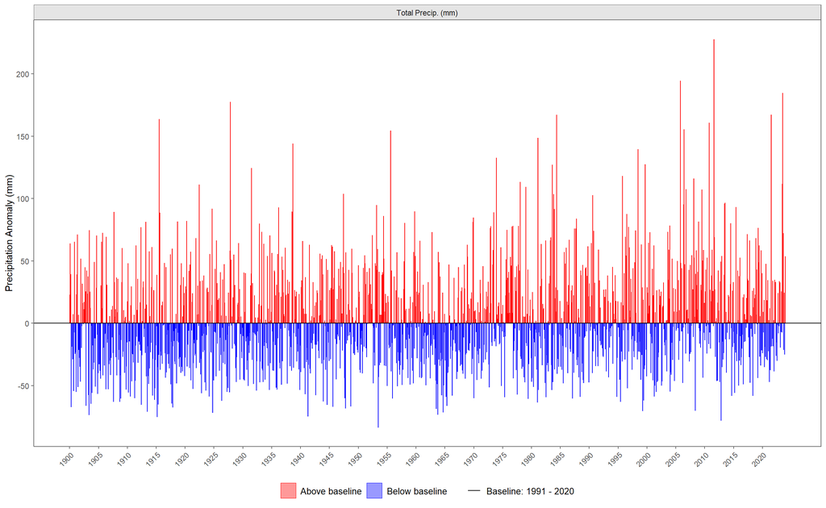

Figure represents monthly deviations from historic baselines, with positive (red) bars, indicated above average deviations, and negative (blue) bars indicating below average deviations. Historic baselines are based on [NOAA 20th century normals](https://www.ncei.noaa.gov/products/land-based-station/us-climate-normals) for a given park’s geographic centroid. Monthly data are derived from [NOAA NClimGrid](https://www.ncei.noaa.gov/access/metadata/landing-page/bin/iso?id=gov.noaa.ncdc:C00332) gridded climate dataset extracted for a given park’s geographic centroid.

## About the Sites

[interactive chart not shown]

## About the Data

Freshwater resources are affected and stressed by natural and anthropogenic (human) impacts and alterations. Current and historic threats to aquatic ecosystems in NPS units throughout the northeastern U.S. have led to specific physical, biological, or chemical stressors to the freshwater ecosystems. The documentation of baseline water quality and water quantity is essential to the long-term maintenance of freshwater resources and for interpreting changes (natural or anthropogenic) that are occurring within and surrounding parks. Monitoring water resources assists natural resource managers in identifying and addressing stressors in park freshwater ecosystems.

The Northeast Temperate Network monitors freshwater bodies to assess the status of and changes in their physical, chemical, and biological attributes. Sampling is performed monthly from May through October. All monitoring data are incorporated into a comprehensive database that feeds into an Environmental Protection Agency data system.

More information about this monitoring program can be found on the [NETN Water Quality and Quantity Website](https://www.nps.gov/im/netn/water-quality-quantity-monitoring.htm). Additional resources can be found in the [NETN Lake, Pond, & Stream Monitoring Program in the Data Store](https://irma.nps.gov/DataStore/Reference/Profile/2190885) (Reference 2190885), including the latest [monitoring protocol](https://irma.nps.gov/DataStore/Reference/Profile/2229872) and [summary reports](https://irma.nps.gov/DataStore/SavedSearch/Profile/1456). If you have questions about the program or this report, please contact Bill Gawley, NETN Physical Scientist.

### Monitoring Frequency

NETN water monitoring sites are sampled monthly from May through October, and most sites are visited annually. Some ACAD sites are visited on a 2-year (streams) or 3-year (lakes) rotating schedule. Each month, field crews measure physical and in situ water quality parameters and collect water samples for chemical analysis at the University of Maine’s Sawyer Environmental Research Center.

### Field Measurements

Temperature, dissolved oxygen, pH, specific conductance, and turbidity are measured with a multiparameter sonde. In lakes, a series of measurements taken at 1 m increments through the water column create a water quality profile, documenting conditions at various depths and lake stratification (when present). In streams, the sonde is deployed in the centroid of the stream flow and a single measurement of each parameter is recorded at each site visit. *Note:* Lake water quality values presented in this report are derived from measurements taken from the top 2 meters of the profile, and represent conditions in the lake surface layer (epilimnion).

Stream flow (discharge) is measured at each site using U.S. Geological Survey protocols. A measuring tape is used to measure a cross-section of the stream, and water velocity is recorded using a wading rod and mechanical or Doppler current meter.

Transparency (water clarity) in lakes is measured with a 20 cm (8 in) Secchi disk fastened to a measuring tape and observed with a viewing scope. Light penetration profiles are recorded using two solar radiation sensors and a datalogger.

### Sample Collection for Lab Chemistry

Stream water is collected by submerging the sample bottle directly in the centroid of the streamflow with a gloved hand. Samples are analyzed for Acid Neutralizing Capacity (ANC), total phosphorus (TP), total nitrogen (TN), and dissolved organic carbon (DOC).

Samples from lakes shallower than 3 m are collected as a half-meter grab sample. Samples from lakes deeper than 3 m are collected with a weighted core sample tube lowered to the bottom of the epilimnion, creating a composite sample of water from all depths of the surface layer. Lake samples are analyzed for Acid Neutralizing Capacity (ANC), total phosphorus (TP), total nitrogen (TN), and chlorophyll *a.*

### Dissolved Oxygen (DO) in mg/L or % saturation

Dissolved oxygen (DO) is a measure of the amount of oxygen in water that is available to living aquatic organisms, and is necessary for the survival and growth of many aquatic organisms. DO can enter water by photosynthesis of plants or directly from the atmosphere, and it is lost by temperature rise, plant and animal respiration, and bio-chemical reactions. The DO concentration of surface water also depends on water temperature and air pressure. High pressures and cool temperatures allow more oxygen to be dissolved in the water. Due to changes in temperature, DO has strong daily and seasonal variability.

Low DO is highly concerning because of its detrimental effects on aquatic life. Conditions that generally contribute to low DO include warm temperatures, low flows, water stagnation, shallow gradients in streams, organic matter inputs, and high respiration rates. Decay of excessive organic debris from aquatic plants, municipal or industrial discharges, or storm runoff can also cause low DO.

There are two measures of DO: milligrams per liter (mg/L) and % saturation. Milligrams per liter indicates the absolute amount of oxygen present in the water, whereas % saturation indicates how much is present as compared to a theoretical maximum determined by water temperature. **Note:** This summary reports DO in mg/L only.

### pH

pH is important to aquatic life because it has a profound impact on the toxicity and solubility of many chemicals, such as ammonia, aluminum, and some other contaminants. This is because changes in pH affect the dissociation of weak acids or bases, which in turn affects their toxicity. For example, hydrogen cyanide toxicity to fish increases with lowered pH, whereas rapid increases in pH increase NH3 (ammonia) concentrations. Metal mobility is also enhanced by low pH, which can have a significant impact on water bodies located in areas contaminated by acid deposition or heavy metals (e.g. mining).

The pH of water is measured on a scale that most commonly ranges from 0 (acid) to 14 (basic/alkaline). The pH scale is logarithmic, meaning each pH unit increase represents a 10x decrease in hydrogen ion concentration. For comparative reference, pure water has a pH of 7 (neutral).

### Specific Conductance

Specific conductance is a temperature-corrected measure of the electrical conductivity of water and is directly related to ion concentration. The capacity of water to conduct an electrical current, i.e. its conductivity, is highly dependent on temperature and may change as much as 3% for each 1°C change. Thus, it is necessary to correct for temperature because a significant change in conductivity may simply be due to water temperature and not due to changes in ions in the water.

Water input, such as from a spring, groundwater, rain, confluence or other sources can affect the conductivity of water. For example, low-conductivity streams typically have less groundwater input than high-conductivity streams. As a result, their flow and temperature regimes are more dynamic. Likewise, reductions in flow from dams or river diversions can also alter conductivity levels. Although an increase in conductivity may indicate an increase of an ion that is toxic to aquatic life, the conductivity of a water body has little to no direct effect on aquatic life. Conductivity also indicates the degree to which a watershed's bedrock and mineral soil resists erosion.

Specific conductance is also useful in estimating the concentration of dissolved solids in water. Electric current is carried by dissolved inorganic solids such as chloride, carbonate, nitrate, sulfate, and phosphate anions (negatively charged particles), as well as sodium, calcium, magnesium, potassium, iron, and aluminum cations (positively charged particles). Anthropogenic discharges to surface waters can change the conductivity. For example, a failing sewage system would raise the conductivity because of the presence of chloride, phosphate, and nitrate, while an oil spill would lower the conductivity. Other common sources of pollution that can affect specific conductance are de-icing salts, dust reducing compounds, and agriculture (primarily from the liming of fields).

Conductivity is measured in microsiemens per centimeter (µS/cm). For reference, distilled water has a conductivity in the range of 0.5 to 3 µS/cm, while the conductivity of rivers in the United States generally ranges from 50 to 1500 µS/cm. Studies of inland fresh waters indicate that streams supporting good mixed fisheries have a range between 150 and 500 µS/cm. Conductivity outside this range could indicate that the water is not suitable for certain species of fish or macroinvertebrates. By contrast, industrial waters can range as high as 10,000 µS/cm.

### Water Temperature

Several of the water chemistry parameters are water temperature dependent, such as DO and specific conductance. High temperature can also stress aquatic organisms, particularly those adapted to habitats with cooler temperatures such as trout. Temperature is reported in °C.

### Acid Neutralizing Capacity (ANC)

ANC is a measure of the amount of compounds in the water that neutralize strong acids, also known as “buffering capacity”. ANC is the prime indicator of a waterbody’s susceptibility to acid inputs, with higher ANC values indicating greater resistance to the effects of acid. The measured ANC refers to the alkalinity of an unfiltered water sample. ANC is typically caused by anions (negatively charged particles) in natural waters that can chemically react with a strong acid. Carbonate (CO<sub>3</sub><sup>2-</sup>) and bicarbonate (HCO<sub>3-</sub>) ions are the most common, although borates, phosphates, silicates, arsenate, and ammonium can also contribute to ANC when present.

### Total Phosphorus (TP)

Phosphorus (P) is one of the major nutrients needed for plant growth. It is generally present in small amounts in natural freshwater systems and typically limits the plant growth in streams and ponds. Several forms of phosphorus can be tested, and total phosphorus (TP) was selected as the most meaningful measure of this nutrient for NETN. TP is a measure of both inorganic and organic forms of phosphorus and is the common water quality standard or criteria metric.

### Total Nitrogen (TN)

Nitrogen (N), often the limiting nutrient in marine waters, is an essential plant element and can also be the limiting nutrient in some freshwater systems. The importance of nitrogen in the aquatic environment varies according to the relative amounts of the forms of nitrogen present, including nitrate, nitrite, and ammonia. Nitrate is one of the dissolved, inorganic forms of nitrogen most available for biological uptake and the chemical transformation that can lead to eutrophication of water bodies. Nitrate is highly mobile in surface and groundwater and may seep into streams, lakes, and estuaries from groundwater enriched by animal or human wastes and commercial fertilizers. High concentrations of nitrate can enhance the growth of algae and aquatic plants in a manner similar to phosphorus enrichment and thus cause eutrophication of a water body. Total nitrogen (TN) is a measure of all forms of nitrogen (organic and inorganic) and was chosen as the most useful N metric for NETN water monitoring.

### Chlorophyll *a*

The amount of chlorophyll *a* in a water sample is a measure of the concentration of suspended phytoplankton and can be used as an indicator of algal biomass and thus of water quality. Chlorophyll *a* is responsible for photosynthesis and is found in various forms within the living cells of algae, phytoplankton, and other aquatic plant matter. Like other biological response variables, chlorophyll *a* tends to integrate the stresses of various parameters over time, and thus is often an important nutrient-stress parameter to measure.

### EPA Ecoregional Nutrient Criteria

EPA water quality criteria by Ecoregion are used as a benchmark in this summary. EPA water quality criteria for nutrients help translate narrative criteria within State or Tribal water quality standards by establishing values for causal variables (e.g., total nitrogen and total phosphorus) and response variables (e.g., turbidity and chlorophyll a). Causal variables are necessary to provide sufficient protection of designated uses before impairment occurs and to maintain downstream uses. Early response variables are necessary to provide warning signs of possible impairment and to integrate the effects of variable and potentially unmeasured nutrient loads.

These criteria are designed to represent conditions of surface waters that are minimally impacted by human activities and thus protect against the adverse effects of nutrient over-enrichment from cultural eutrophication. The values are EPA’s scientific recommendations regarding ambient concentrations of nutrients that protect aquatic resource quality. They do not have any regulatory impact or meaning.

[output not shown]

| Streams | TP (ug/L) | TN (mg/L) | Salinity as Conductivity (ug/L) |
| --- | --- | --- | --- |
| Least disturbed | 17.1 | 0.345 | 500 |
| Most disturbed | 32.6 | 0.482 | 1000 |

### Vermont State Water Quality Standards

In all waters in Vermont, “the change or rate of change in temperature, either upward or downward, shall be controlled to ensure full support of aquatic biota, wildlife, and aquatic habitat uses… [For cold water fish habitat,] the total increase from the ambient temperature resulting from all activities shall not exceed 1°F." In lakes, ponds, and reservoirs the total increase from ambient temperature shall not exceed 1°F if the ambient temperature is above 60°F; 2°F if the ambient temperature is between 50 and 60°F; and 3°F if the ambient temperature is below 50°F. In all other waters, the totaly increase from ambient temperature shall not exceed 1°F if the ambient temperature is above 66°F; 2°F if the ambient temperature is between 63 and 66°F; 3°F if the ambient temperature is between 59 and 62°F; 4°F if the ambient temperature is between 55 and 58°F; and 5°F if the ambient temperature is below 55°F.

All total phosphorus and nitrate concentrations “shall be limited so that they will not contribute to the acceleration of eutrophication or the stimulation of the growth of aquatic biota in a manner that prevents the full support of uses”. In lakes, ponds, and reservoirs, nitrate concentrations are “not to exceed 5.0 mg/L as NO3-N regardless of classification”. In class A(1) waters, nitrates are “not to exceed 2.0 mg/L as NO3-N at flows exceeding low median monthly flows”.

There should be no color “that would prevent the full support of uses,” and pH “shall be maintained with the range of 6.5 and 8.5”. Turbidity will not be present “in such amounts or concentrations that would prevent the full support of uses, and not to exceed 10 NTU… as an annual average under dry weather base-flow conditions”.

DO concentrations are as naturally occurs in all Class A(1) ecological waters. DO concentrations in cold water fish habitat is “not less than 7 mg/L and 75 percent saturation at all times, nor less than 95 percent saturation during late egg maturation and larval development of salmonids in areas that the Secretary determines are salmonid spawning or nursery areas important to the establishment or maintenance of the fishery resource. Not less than 6 mg/L and 70 percent saturation at all times in all other waters designated as a cold water fish habitat.” In warm water fish habitat DO concentrations are “not less than 5 mg/L and 60 percent saturation at all times”.

### Vermont stream water quality standards

[output not shown]

### Vermont lake and pond water quality standards

[output not shown]

*Note: When quantitative state water quality standards are not defined, EPA water quality thresholds are used (see EPA Ecoregional Nutrient Criteria tables above).*

##### EXPERIENCE YOUR AMERICA ™